# hw3

## Directions

1. Download and read the Kirb21 data here https://raw.githubusercontent.com/smart-stats/ds4bio_book/main/book/assetts/kirby21AllLevels.csv into pandas. Name your dataframe "kirb21_df"
2. Obtain a dataset for the subject with "rawid" equal to "kirby906a_ax.img". Name it "kirby906a_ax_df" and do the following.
3. Write code to calculate this subject's volume of their type I level I telencephalon (left annd right). Name the variables "telencephalon_L_volume" and "telencephalon_R_volume" such that when printed only the volume is printed (do not make it a dataframe, series, etc. only a number!). Also, find the fractions of the ICV and TBV made up by their left and right telencelphalons. Name the variables "ICV_fraction" and "TBV_fraction" and print them out as well.
4. Create a dataframe that has the sum of all of the regions for every type and level, name it "all_regions_df". So, it should have three columns, type, level and total_volume.
5. Create a bar plot to visualize this subject's Type 1 Level 2 data using seaborn or matplotlib.
6. Create a donut chart in matplotlib of the Type 1 Level 3 ROI data.
7. Read in the class data from here https://github.com/bcaffo/ds4bme/blob/master/data/classInterests.txt Name it "class_interests_df". Create a single bar plot of student counts by year and program using seaborn.
8. Download the gene expression dataset from here https://github.com/jhu-advdatasci/2018/blob/master/data/GSE5859_exprs.csv Name it "gene_expression_df". Information about the data can be found in the sample info here. https://github.com/jhu-advdatasci/2018/blob/master/data/GSE5859_sampleinfo.csv Do the following operations on the gene expression matrix: i) subtract the rowmean from each row (name it "gene_expression_df_pt1") and 2) take the resulting matrix and subtract the column mean from each column (name it "gene_expression_df_pt2") 3) Take the resulting matrix and divide each column by the column's standard deviation (name it "gene_expression_df_pt3").
9. Download the data from here https://raw.githubusercontent.com/jhu-advdatasci/2018/master/data/KFF/healthcare-spending.csv Name it "healthcare_df". Create a plot of healthcare spending versus time color coded by states. The option skiprows = 2 is useful in pd.read_csv for this dataset since there's two lines of metadata at the top of the file. Refer to the previous data. Create a barplot using matplotlib of average health care spending by state.

```python
#setup
import pandas as pd
import numpy as np
import matplotlib as mpl
import matplotlib.pyplot as plt
import seaborn as sns
import plotly.express as px
import plotly.io as pio

pio.renderers.default = 'notebook'
```

## Question 1 & 2

```python
kirb21_df=pd.read_csv("https://raw.githubusercontent.com/smart-stats/ds4bio_book/main/book/assetts/kirby21AllLevels.csv")
kirby906a_ax_df = kirb21_df.loc[kirb21_df["rawid"] == "kirby906a_ax.img"]
kirby906a_ax_df.head()
```

|  | Unnamed: 0 | rawid | roi | volume | min | max | mean | std | type | level | id | icv | tbv |
| --- | --- | --- | --- | --- | --- | --- | --- | --- | --- | --- | --- | --- | --- |
| 12540 | 12541 | kirby906a_ax.img | Telencephalon_L | 467063 | 2.0 | 350.0 | 165.2599 | 57.1707 | 1 | 1 | 906 | 1195015 | 1123076 |
| 12541 | 12542 | kirby906a_ax.img | Telencephalon_R | 470488 | 2.0 | 337.0 | 171.8695 | 59.3001 | 1 | 1 | 906 | 1195015 | 1123076 |
| 12542 | 12543 | kirby906a_ax.img | Diencephalon_L | 8801 | 60.0 | 327.0 | 227.1878 | 31.2303 | 1 | 1 | 906 | 1195015 | 1123076 |
| 12543 | 12544 | kirby906a_ax.img | Diencephalon_R | 9054 | 63.0 | 415.0 | 231.6770 | 31.1780 | 1 | 1 | 906 | 1195015 | 1123076 |
| 12544 | 12545 | kirby906a_ax.img | Mesencephalon | 9564 | 86.0 | 352.0 | 269.1003 | 28.6454 | 1 | 1 | 906 | 1195015 | 1123076 |

## Question 2a

```python
telencephalon_L_volume = kirby906a_ax_df.loc[
    (kirby906a_ax_df["type"] == 1) &
    (kirby906a_ax_df["level"] == 1) &
    (kirby906a_ax_df["roi"] == "Telencephalon_L"),
    "volume"
].iloc[0]

telencephalon_R_volume = kirby906a_ax_df.loc[
    (kirby906a_ax_df["type"] == 1) &
    (kirby906a_ax_df["level"] == 1) &
    (kirby906a_ax_df["roi"] == "Telencephalon_R"),
    "volume"
].iloc[0]

print(telencephalon_L_volume)
print(telencephalon_R_volume)


ICV = kirby906a_ax_df["icv"].iloc[0]
TBV = kirby906a_ax_df["tbv"].iloc[0]

total_telencephalon = telencephalon_L_volume + telencephalon_R_volume
ICV_fraction = total_telencephalon / ICV
TBV_fraction = total_telencephalon / TBV

print(ICV_fraction)
print(TBV_fraction)
```

```
467063
470488
0.7845516583473847
0.8348063710737297
```

## Question 2b

```python
all_regions_df = kirby906a_ax_df.groupby(['type', 'level'])['volume'].sum().reset_index()
all_regions_df.head()
```

|  | type | level | volume |
| --- | --- | --- | --- |
| 0 | 1 | 1 | 1195015 |
| 1 | 1 | 2 | 1195021 |
| 2 | 1 | 3 | 1195034 |
| 3 | 1 | 4 | 1195065 |
| 4 | 1 | 5 | 1195124 |

## Question 2c

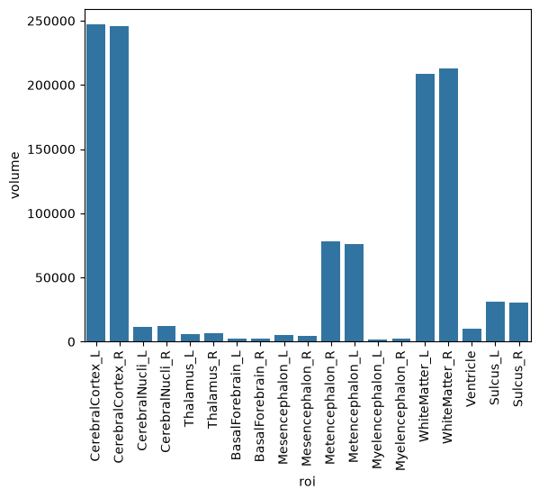

```python
type1_level2_df = kirby906a_ax_df.loc[
    (kirby906a_ax_df['type'] == 1) &
    (kirby906a_ax_df['level'] == 2)
]
sns.barplot(data=type1_level2_df, x='roi', y='volume')
plt.xticks(rotation=90)
plt.show()
```

```python
type1_level3_df = kirby906a_ax_df.loc[
    (kirby906a_ax_df['type'] == 1) &
    (kirby906a_ax_df['level'] == 3)
]
type1_level3_df.head()
```

|  | Unnamed: 0 | rawid | roi | volume | min | max | mean | std | type | level | id | icv | tbv |
| --- | --- | --- | --- | --- | --- | --- | --- | --- | --- | --- | --- | --- | --- |
| 12567 | 12568 | kirby906a_ax.img | Frontal_L | 79044 | 2.0 | 276.0 | 115.1860 | 32.1059 | 1 | 3 | 906 | 1195015 | 1123076 |
| 12568 | 12569 | kirby906a_ax.img | Frontal_R | 75534 | 7.0 | 278.0 | 114.8270 | 29.2461 | 1 | 3 | 906 | 1195015 | 1123076 |
| 12569 | 12570 | kirby906a_ax.img | Parietal_L | 42615 | 8.0 | 220.0 | 110.9892 | 26.9052 | 1 | 3 | 906 | 1195015 | 1123076 |
| 12570 | 12571 | kirby906a_ax.img | Parietal_R | 44044 | 2.0 | 245.0 | 117.4512 | 29.5736 | 1 | 3 | 906 | 1195015 | 1123076 |
| 12571 | 12572 | kirby906a_ax.img | Temporal_L | 58034 | 10.0 | 261.0 | 123.3465 | 29.5899 | 1 | 3 | 906 | 1195015 | 1123076 |

## Question 2d

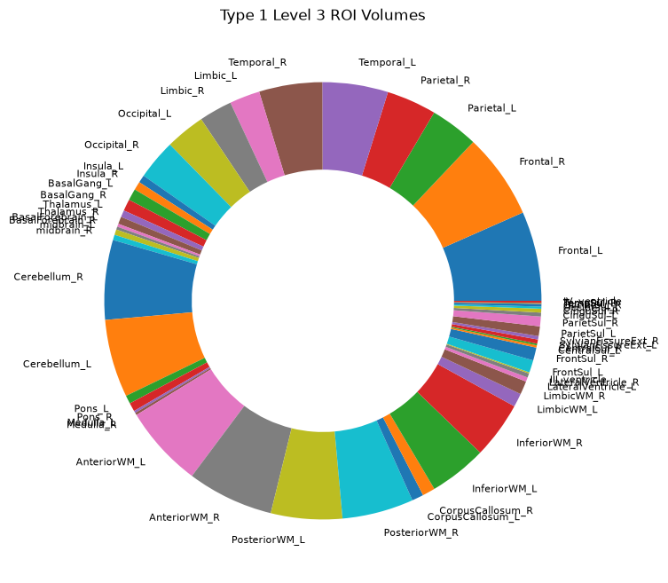

```python
plt.figure(figsize=(8, 8))

plt.pie(
    type1_level3_df['volume'],
    labels=type1_level3_df['roi'],
    wedgeprops={'width': 0.4},
    textprops={'fontsize': 8}
)

plt.title('Type 1 Level 3 ROI Volumes')
plt.show()
```

## Question 3

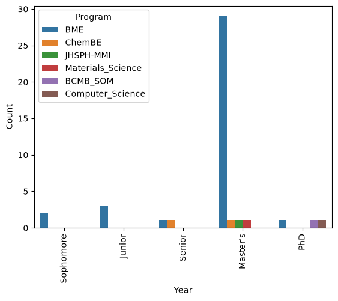

```python
class_interests_df = pd.read_csv(
    "https://raw.githubusercontent.com/bcaffo/ds4ph-bme/refs/heads/master/data/classInterests.txt",
    sep='\t'
)
class_interests_df.head()

counts = class_interests_df.groupby(['Year', 'Program']).size().reset_index(name='Count')

sns.barplot(data=counts, x='Year', y='Count', hue='Program', order=['Sophomore', 'Junior', 'Senior', "Master's", 'PhD'])
plt.xticks(rotation=90)
plt.show()
```

## Question 4

```python
gene_expression_df = pd.read_csv("https://raw.githubusercontent.com/jhu-advdatasci/2018/refs/heads/master/data/GSE5859_exprs.csv",
                                 index_col=0
)
gene_expression_df.head()
```

|  | GSM25581.CEL.gz | GSM25681.CEL.gz | GSM136524.CEL.gz | GSM136707.CEL.gz | GSM25553.CEL.gz | GSM136676.CEL.gz | GSM136711.CEL.gz | GSM136542.CEL.gz | GSM136535.CEL.gz | GSM25399.CEL.gz | ... | GSM48650.CEL.gz | GSM25687.CEL.gz | GSM25685.CEL.gz | GSM136549.CEL.gz | GSM25427.CEL.gz | GSM25525.CEL.gz | GSM25349.CEL.gz | GSM136727.CEL.gz | GSM25626.CEL.gz | GSM136725.CEL.gz |
| --- | --- | --- | --- | --- | --- | --- | --- | --- | --- | --- | --- | --- | --- | --- | --- | --- | --- | --- | --- | --- | --- |
| 1007_s_at | 6.333951 | 5.736190 | 6.156754 | 6.513010 | 6.061013 | 6.506493 | 6.863426 | 6.369645 | 6.646321 | 5.810930 | ... | 7.082636 | 6.315866 | 7.010165 | 6.460107 | 6.122355 | 6.330314 | 6.627014 | 6.133068 | 6.419444 | 6.488579 |
| 1053_at | 7.255622 | 7.399993 | 7.491967 | 7.006123 | 7.250995 | 7.082581 | 6.842236 | 7.048487 | 7.042361 | 6.666625 | ... | 6.599718 | 7.412731 | 7.274429 | 6.928642 | 7.168782 | 7.235648 | 6.939184 | 7.280781 | 6.351776 | 7.517410 |
| 117_at | 5.760106 | 4.825169 | 5.039387 | 5.414160 | 5.205697 | 5.300078 | 5.099337 | 5.156459 | 5.736109 | 5.807496 | ... | 6.231457 | 5.240717 | 5.275062 | 5.759827 | 5.409720 | 5.491938 | 5.113570 | 5.401876 | 5.537605 | 5.247190 |
| 121_at | 6.935451 | 7.025210 | 7.543667 | 7.959781 | 7.223323 | 8.006816 | 8.102504 | 7.434617 | 7.532321 | 7.711461 | ... | 8.215096 | 7.677593 | 7.923624 | 7.219401 | 7.432338 | 6.785174 | 7.833862 | 7.607461 | 7.302935 | 7.331864 |
| 1255_g_at | 3.597872 | 3.108801 | 3.128269 | 3.364947 | 3.125909 | 3.186834 | 3.311022 | 3.092042 | 3.167737 | 2.969579 | ... | 3.331424 | 3.043856 | 3.151900 | 3.132253 | 3.250600 | 2.984125 | 3.152269 | 3.225123 | 3.222731 | 3.175846 |

5 rows × 208 columns

```python
rowmean = gene_expression_df.mean(axis=1)
gene_expression_df_pt1 = gene_expression_df.sub(rowmean, axis=0)
```

```python
colmean = gene_expression_df_pt1.mean(axis=0)
gene_expression_df_pt2 = gene_expression_df_pt1.sub(colmean, axis=1)
```

```python
colstd = gene_expression_df_pt2.std(axis=0)
gene_expression_df_pt3 = gene_expression_df_pt2.div(colstd, axis=1)
gene_expression_df_pt3.head()
```

|  | GSM25581.CEL.gz | GSM25681.CEL.gz | GSM136524.CEL.gz | GSM136707.CEL.gz | GSM25553.CEL.gz | GSM136676.CEL.gz | GSM136711.CEL.gz | GSM136542.CEL.gz | GSM136535.CEL.gz | GSM25399.CEL.gz | ... | GSM48650.CEL.gz | GSM25687.CEL.gz | GSM25685.CEL.gz | GSM136549.CEL.gz | GSM25427.CEL.gz | GSM25525.CEL.gz | GSM25349.CEL.gz | GSM136727.CEL.gz | GSM25626.CEL.gz | GSM136725.CEL.gz |
| --- | --- | --- | --- | --- | --- | --- | --- | --- | --- | --- | --- | --- | --- | --- | --- | --- | --- | --- | --- | --- | --- |
| 1007_s_at | -0.062810 | -1.694428 | -0.797346 | 0.362538 | -1.152413 | 0.366177 | 1.252187 | -0.054154 | 1.008166 | -0.730639 | ... | 1.446603 | -0.185273 | 1.615970 | 0.245537 | -0.568262 | -0.069236 | 0.617954 | -0.598607 | 0.088393 | 0.257410 |
| 1053_at | 0.484259 | 0.835005 | 1.434085 | -0.316432 | 0.141554 | -0.076237 | -0.745136 | -0.148166 | -0.250652 | -0.497815 | ... | -1.094982 | 0.985940 | 0.538265 | -0.521649 | 0.195814 | 0.365237 | -0.422815 | 0.408542 | -1.573530 | 1.173822 |
| 117_at | 0.789673 | -1.707110 | -1.548943 | -0.245036 | -1.015618 | -0.637799 | -1.096388 | -1.031533 | 0.992122 | 0.696068 | ... | 1.564055 | -0.694512 | -0.395453 | 0.904341 | -0.130702 | 0.080440 | -0.977132 | -0.197351 | 0.140632 | -0.701024 |
| 121_at | -1.599798 | -1.460817 | -0.134750 | 1.138467 | -1.255766 | 1.368016 | 1.357039 | -0.486577 | -0.260531 | 0.375192 | ... | 1.300847 | 0.299944 | 0.918732 | -1.166704 | -0.321440 | -1.714599 | 0.633897 | 0.028623 | -0.591095 | -0.764897 |
| 1255_g_at | 1.090032 | -0.216675 | -0.238137 | 0.480868 | -0.479461 | -0.082265 | 0.247916 | -0.347177 | -0.172784 | -0.186654 | ... | 0.239831 | -0.445844 | -0.016443 | -0.209588 | 0.141031 | -0.423519 | -0.141661 | 0.037831 | 0.064544 | -0.106213 |

5 rows × 208 columns

## Question 5

```python
healthcare_df = pd.read_csv ("https://raw.githubusercontent.com/jhu-advdatasci/2018/master/data/KFF/healthcare-spending.csv",
                             skiprows=2,
                             nrows=52
)
healthcare_df.head()
```

|  | Location | 1991__Total Health Spending | 1992__Total Health Spending | 1993__Total Health Spending | 1994__Total Health Spending | 1995__Total Health Spending | 1996__Total Health Spending | 1997__Total Health Spending | 1998__Total Health Spending | 1999__Total Health Spending | ... | 2005__Total Health Spending | 2006__Total Health Spending | 2007__Total Health Spending | 2008__Total Health Spending | 2009__Total Health Spending | 2010__Total Health Spending | 2011__Total Health Spending | 2012__Total Health Spending | 2013__Total Health Spending | 2014__Total Health Spending |
| --- | --- | --- | --- | --- | --- | --- | --- | --- | --- | --- | --- | --- | --- | --- | --- | --- | --- | --- | --- | --- | --- |
| 0 | United States | 675896 | 731455 | 778684 | 820172 | 869578 | 917540 | 969531 | 1026103 | 1086280 | ... | 1696222 | 1804672 | 1918820 | 2010690 | 2114221 | 2194625 | 2272582 | 2365948 | 2435624 | 2562824 |
| 1 | Alabama | 10393 | 11284 | 12028 | 12742 | 13590 | 14450 | 15462 | 15860 | 16451 | ... | 25338 | 26638 | 27700 | 28765 | 30095 | 30728 | 31398 | 32848 | 33788 | 35263 |
| 2 | Alaska | 1458 | 1558 | 1661 | 1728 | 1879 | 2076 | 2240 | 2386 | 2569 | ... | 4765 | 5048 | 5426 | 5807 | 6112 | 6519 | 6928 | 7406 | 7684 | 8151 |
| 3 | Arizona | 9269 | 9815 | 10655 | 11364 | 12042 | 12850 | 13418 | 14465 | 15550 | ... | 28190 | 30766 | 33366 | 35547 | 37258 | 38620 | 39295 | 40495 | 41481 | 43356 |
| 4 | Arkansas | 5632 | 6022 | 6397 | 6810 | 7343 | 7817 | 8393 | 8814 | 9407 | ... | 14611 | 15431 | 16426 | 17246 | 18071 | 18735 | 19356 | 20076 | 20500 | 21980 |

5 rows × 25 columns

```python
healthcare_long_df = healthcare_df.melt(
    id_vars='Location',
    var_name='Year',
    value_name='Total Health Spending'
)
```

```python
healthcare_long_df['Year'] = healthcare_long_df['Year'].astype(str).str[:4].astype(int)

# Remove United States total
healthcare_long_df = healthcare_long_df.loc[
    healthcare_long_df['Location'] != 'United States'
]

#  Interactive plot because theres so many states
fig = px.line(
    healthcare_long_df,
    x='Year',
    y='Total Health Spending',
    color='Location',
    hover_name='Location',
    title='Healthcare Spending by State',
    markers=True
)
fig.update_layout(
    width=1000,
    height=600,
    showlegend=True,
    legend=dict(
        title='State',
        x=1.02,
        y=1,
        xanchor='left',
        yanchor='top'
    ),
    xaxis_title='Year',
    yaxis_title='Total Health Spending'
)

fig.show()
```

[interactive chart not shown]

## Question 6

```python
healthcare_avgs=healthcare_long_df.groupby('Location')['Total Health Spending'].mean().reset_index().sort_values(by='Total Health Spending', ascending=False)

healthcare_avgs.head()
```

|  | Location | Total Health Spending |
| --- | --- | --- |
| 4 | California | 165824.708333 |
| 32 | New York | 120398.416667 |
| 43 | Texas | 102809.375000 |
| 9 | Florida | 93009.750000 |
| 38 | Pennsylvania | 72803.083333 |

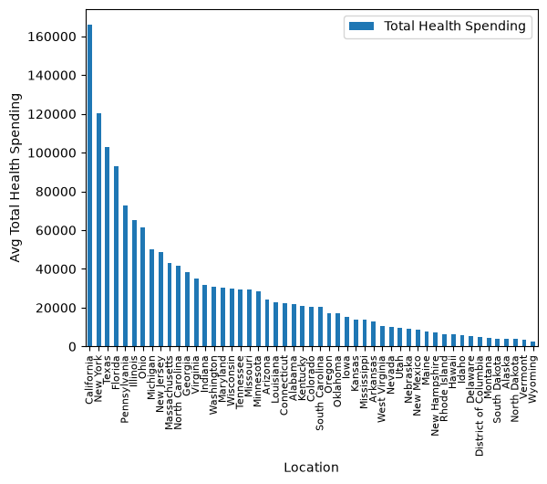

```python
healthcare_avgs.plot(kind='bar', x='Location', y='Total Health Spending')

plt.ylabel('Avg Total Health Spending')
plt.xticks(rotation=90, fontsize=8)
plt.show()
```